# Cartograflow

Filtering Matrix for Thematic Flow Mapping

Françoise Bahoken, Sylvain Blondeau

2020-05-17

`Cartograflow` is designed to filter origin-destination (OD) flow for thematic mapping purposes (see Reference), using `{sf}` objects and `{Cartography}` to design the map.

## Description of functions

**1. Preparing flow data sets:**

**1.1 General functions** You can use long “L” or matrix “M” [n*n] flow dataset formats.

– `flowtabmat()` is to transform “L” to “M” formats, also to build an empty square matrix from spatial codes.

– `flowcarre()` is to square a matrix.

– `flowjointure()` is to performs a spatial join between a flow dataset and a spatial features layer or an external matrix.

– `flowstructmat()` fixes an unpreviously codes shift in the flow dataset “M” format. If necessary this function is to be used with `flowjointure` and `flowtabmat`.

**1.2. Flow computing:**

– `flowtype()` is to compute volumn and balance flow from observed flows - respectively to compute symetric and skewmetric matrix from an asymmetric one.

**1.3. Flow reduction:**

– `flowreduct()` is to reduce the flow dataset regarding another matrix, e.g. distances travelled.

- `metric` is the metric of the distance matrix : *continuous* (e.g. for meters) or *ordinal* (e.g. for adjacency).

If the metric is continuous (e.g for filtering flows by kilometric distances travelled), use:

- `d.criteria` is for selecting *dmin* or *dmax* distance criteria for “continuous” metric ; Argument `dmin` is for keeping only flows up to a *dmin* criterion in km ; Argument `dmax` for selecting values less than a *dmax* criterion in km.
- `d` is the value of the selected *dmin* or *dmax* criteria.

Notice that these arguments can be used as a filter criterion in `flowmap()`.

See Cartograflow_distance and Cartograflow_ordinal_distance Vignettes for examples.

**2. Filtering flows:**

**2.1. Filtering from flow concentration analysis**

**Flow concentration analysis:**

– `flowgini()` performs a Gini’s concentration analysis of the flow features, by computing *Gini coefficient* and plotting interactive *Lorenz curve*.

To be use before `flowanalysis()`

See Cartograflow_concentration Vignette for example.

**Flow filtering according to a concentration criterion:**

– `flowanalysis()` computes filters criterions based on:

- argument *critflow* is to filter the flows according to their significativity (% of total of flow information) ;
- argument *critlink* is to filter the flows according to their density (% of total features)

These arguments can be used as filter criterion in `flowmap()`.

See Cartograflow_concentration Vignette for example.

**2.2. Spatial / territorial filtering of flows**

**Flow filtering based on a continuous distance criterion**

– `flowdist()` computes a *continous distance* matrix from spatial features (area or points). The result is a matrix of the distances travelled between ODs, with flows filtered or not.

See Cartograflow_distance Vignette for example.

**Flow filtering based on an ordinal distance / neighbourhood criterion**:

– `flowcontig()` compute an *ordinal distance* matrix from spatial features (area). The result is a matrix of adjacency or k-contiguity of the ODs.

- `background` is the areal spatial features ;
- `code` is the spatial features codes ;
- `k` is to enter the number (k:1,2,…,k) of the contiguity matrix to be constructed : if (k=1), ODs places are adjacent, then the flow have to cross only 1 boundary, else (k=k) ODs places are distant from n borders ;
- `algo` is the algorithm to use for ordinal distance calculation (also Default is “automatic” for “Dijkstra’s”) ;

Notice that the function automatically returns the maximum (k) number of the spatial layer.

See Cartograflow_distance_ordinal Vignette for example.

**3. Flow mapping**

– `flowmap()` is to plot flows as segments or arrows, by acting on the following arguments:

- `filter` is to filter or not flow’s information or features
- `threshold` is used to set the filtering level of the flows when filter=“True”
- `taille` is the value of the width of the flow feature
- `a.head` is the arrow head parameter (in, out, in and out)
- `a.length` is the length of the edges of the arrow head (in inches)
- `a.angle` is the angle from the shaft of the arrow to the edge of the arrow head
- `a.col` is the arrow’s color
- `plota` is to add spatial features as map background to the flows’s plot
- `add` is to allow to overlay flow features on external spatial features background

## Examples of applications

– **Useful packages** Best external R package to use: {dplyr} {sf} {igraph} {rlang} {cartography}

## **1. Load datasets**

**Flow dataset**

```r
# Load Statistical information
data<-read.csv2("./data/MOBPRO_ETP.csv",
               header=TRUE,
               sep=";",
               stringsAsFactors=FALSE,
               encoding="UTF-8",
               dec=".",
               check.names=FALSE)

str(data)
```

```
## 'data.frame':    121 obs. of  4 variables:
##  $ i    : chr  "T1" "T1" "T1" "T1" ...
##  $ j    : chr  "T1" "T10" "T11" "T12" ...
##  $ Fij  : int  291058 8297 3889 17064 12163 32682 81129 16622 25317 1962 ...
##  $ count: int  351 43 13 77 52 55 134 63 53 14 ...
```

```r
# Variable typing
data$i<-as.character(data$i)
data$j<-as.character(data$j)
data$Fij<-as.numeric(data$Fij)
data$count<-as.numeric(data$count)
```

**Select variable and change matrix format**

```r
# Selecting useful variables
tabflow<-data%>%select(i,j,Fij)

# Change matrix format (if necessary)
matflow <-flowtabmat(tabflow,matlist="M")
```

```
## great:your matrix is square!
```

```r
head(matflow[1:4,1:4])
```

```
##         T1   T10   T11   T12
## T1  291058  8297  3889 17064
## T10  73743 19501 11707  4931
## T11  22408  9359 12108  6084
## T12  68625  1906  7269 46515
```

```r
#dim(matflow)

# reverse : matrix to list format
tabflow<-flowtabmat(tab=matflow,
                    matlist="L")
colnames(tabflow)<-c("i","j","Fij")
head(tabflow)
```

```
##     i  j    Fij
## 1  T1 T1 291058
## 2 T10 T1  73743
## 3 T11 T1  22408
## 4 T12 T1  68625
## 5  T2 T1  47427
## 6  T3 T1  45772
```

**Geographical dataset**

```r
# Load a list of geo codes
ID_CODE<-read.csv2("./data/COD_GEO_EPT.csv",
                   header=TRUE,
                   sep=";",
                   stringsAsFactors=FALSE,
                   encoding="UTF-8",
                   dec=".",
                   check.names=FALSE)
#head(ID_CODE)

CODE<-ID_CODE%>% dplyr::select(COD_GEO_EPT)

colnames(CODE)<-c("CODGEO")
#head(CODE)
```

## **2. Flow computing**

*Compute bilateral flows : volum, balance and asymetry*

```r
# Compute bilateral volum : FSij
matflow_vol<-flowtype(matflow,
                      format="M",
                      "bivolum")

tabflow_vol<-flowtype(tabflow,
                     format="L",
                     "bivolum")

# Compute bilateral balance : FSij
tabflow_net<-flowtype(tabflow,
                      format="L",
                      "bisold")

# Compute all types of bilateral flows, in one 6 columns "L"format matrix
tabflow_all<-flowtype(tabflow,
                      format="L",
                      x="all")
head(tabflow_all)
```

```
##    i   j    Fij    Fji   FSij  FDij
## 1 T1  T1 291058 291058 582116     0
## 2 T1 T10   8297  73743  82040 65446
## 3 T1 T11   3889  22408  26297 18519
## 4 T1 T12  17064  68625  85689 51561
## 5 T1  T2  12163  47427  59590 35264
## 6 T1  T3  32682  45772  78454 13090
```

```r
# Compute flow asymetry
tabflow_all$FAsy<-(tabflow_all$FDij / tabflow_all$FDij)*100
```

## **3. Direct flow mapping**

**3.1. Plot all origin-destination without any filtering criterion**

The result will reveal a graphic complexity (“spaghetti-effect”")

```r
library(sf)
data(flowdata)
map <- st_read(system.file("shape/MGP_TER.shp", package = "cartograflow"))
knitr::opts_chunk$set(fig.width=6, fig.height=6)
par(mar=c(0,0,1,0))
extent <- c(2800000, 1340000, 6400000, 4800000)
resolution<-150
```

Plot links

```r
# Add and overlay spatial background
par(bg = "NA")

knitr::opts_chunk$set(fig.width=6, fig.height=6)
par(mar=c(0,0,1,0))
extent <- c(2800000, 1340000, 6400000, 4800000)
resolution<-150

# Add the corresponding background
plot(st_geometry(map), col = NA, border=NA, bg="#dfe6e1")
plot(st_geometry(map), col = "light grey", add=TRUE)


# Flowmapping of all links

flowmap(tab=tabflow,
        fij="Fij",
        origin.f = "i",
        destination.f = "j",
        bkg = map,
        code="EPT_NUM",
        nodes.X="X",
        nodes.Y = "Y",
        filter=FALSE,
        add=TRUE
        )
```

```
## All theorical links are plotted
```

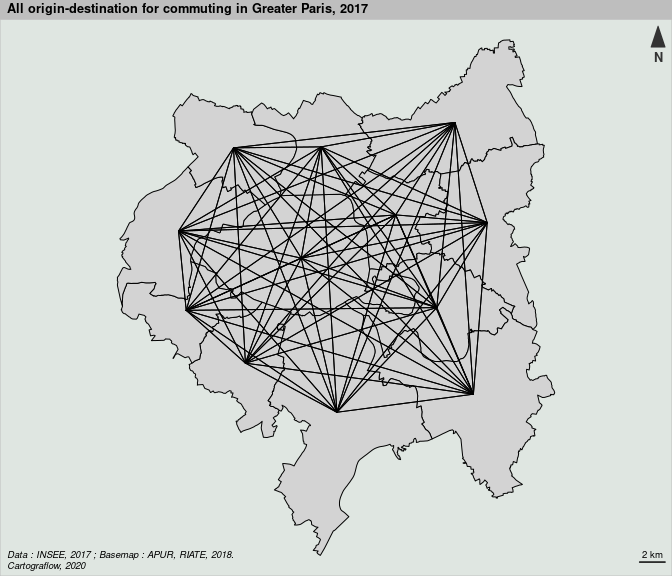

```r
# Map cosmetics
layoutLayer(title = "All origin-destination for commuting in Greater Paris, 2017",
           coltitle ="black",
           author = "Cartograflow, 2020",
           sources = "Data : INSEE, 2017 ; Basemap : APUR, RIATE, 2018.",
           scale = 2,
           tabtitle = FALSE,
           frame = TRUE,
           col = "grey"
            )
# North arrow
north("topright")
```

**3.2. Plot the above-average flows**

[figure not shown]

```r
library(sf)
data(flowdata)
map <- st_read(system.file("shape/MGP_TER.shp", package = "cartograflow"))
# Add and overlay spatial background
par(bg = "NA")

knitr::opts_chunk$set(fig.width=6, fig.height=6)
par(mar=c(0,0,1,0))
extent <- c(2800000, 1340000, 6400000, 4800000)
resolution<-150

plot(st_geometry(map), col = NA, border=NA, bg="#dfe6e1")
plot(st_geometry(map), col = "light grey", add=TRUE)

# Flow mapping above-average flows
flowmap(tab=tabflow,
        fij="Fij",
        origin.f = "i",
        destination.f = "j",
        bkg = map,
        code="EPT_NUM",
        nodes.X="X",
        nodes.Y = "Y",
        filter=TRUE,
        threshold =(mean(tabflow$Fij)),  #mean value is the level of threshold
        taille=20,
        a.head = 1,
        a.length = 0.11,
        a.angle = 30,
        a.col="#138913",
        add=TRUE)

# Map Legend
legendPropLines(pos="topleft",
                title.txt="Flows up to 13220 commuters",
                title.cex=0.8,
                cex=0.5,
                values.cex= 0.7,
                var=c(mean(tabflow$Fij),max(tabflow$Fij)),
                lwd=5,
                frame = FALSE,
                col="#138913",
                values.rnd = 0
                )

#Map cosmetic

layoutLayer(title = "Commuters up to above-average in Greater Paris",
           coltitle ="black",
           author = "Cartograflow, 2020",
           sources = "Data : INSEE, 2017 ; Basemap : APUR, RIATE, 2018.",
           scale = 2,
           tabtitle = FALSE,
           frame = TRUE,
           col = "grey"
            )

# North arrow
north("topright")
```

## Sample datasets

– *Statistical dataset* : - INSEE - Base flux de mobilité (2015) -URL : https://www.insee.fr/fr/statistiques/fichier/3566008/rp2015_mobpro_txt.zip

– *Geographical dataset* :

- municipalities : IGN, GEOFLA 2015 v2.1
- Greater Paris : APUR, UMS 2414 RIATE, 2018.

## See also

– cartograflow_general.html  
– cartograflow_concentration.html  
– cartograflow_distance.html  
– cartograflow_ordinal_distance.hmtl

## Reference

– Bahoken Francoise (2016), Programmes pour R/Rtudio annexés, in : *Contribution à la cartographie d’une matrix de flux*, Thèse de doctorat, Université Paris 7, pp. 325-346. URL : https://halshs.archives-ouvertes.fr/tel-01273776, pp. 480-520.